# Seurat_Code_QC_2020

## R Markdown

Begin by installing and loading necessary packages. Unhash the “install” script if you need to install them. You only need to install once per machine, unless you want to update.

```r
#install.packages("BiocManager")
#BiocManager::install("Seurat")
#BiocManager::install("ggplot2")
#install.packages("dplr")
#install.packages("ape")
#install.packages("cowplot")
#install.packages("Matrix")
```

Load packages into your workspace.

```r
library(Seurat)
library(ggplot2)
library(dplyr)
library(ape)
library(cowplot)
library(Matrix)

#find out where you are
getwd()
```

```
## [1] "/Users/whippoorwill/Desktop/Code/scrnaseq"
```

*Edit the following code every time* and make sure the folders “QC” and … are present in the “dir” folder above

```r
#Specify your preferred directory for all input + output
dir= "/Users/whippoorwill/Desktop/Sequencing/LD_AVM02"

#Specify exactly where your matrix files/raw data live
datafolder = "Data/CellRanger"

#Add in any folder name within each sample that leads to your data files:
innerfolder = "filtered_feature_bc_matrix"

#Specify what kind of data you have: "CellRanger" Output (barcodes + matrix .tsv files) or "counts" data (usually something ending in counts.tsv)
datatype = "CellRanger"

#if "datatype" = "counts", specify "filename", otherwise "NA" or "NULL"
filename = "GEX_counts.tsv.gz"

#Set minimums for genes/cell (min.features) and cell expressing a given gene (min.cells). Default is 1/1, you can filter later. If the object is very large, filter here.
min.cells = 1
min.features = 1

#Name your project something descriptive
project<-"Microglia_BC"

#Specify your organism; please capitalize the first letter (i.e. "Mouse", "Human","Zebrafish","Rat")
organism = "Mouse"

#Add in metadata. You may want to run the next chunk and then return to edit this so it is in the same order as "ids"
age = c(rep("P5",2),rep("P7",2))
condition = c("Deprived","Control","Deprived","Control")

#metrics you want to look at for QC
m = c("nCount_RNA","nFeature_RNA","percent.mito")

#set up folders
QCfolder = "QC"
```

*Please note you will also have to edit the thresholding chunk below, line 258. You may run everything up until then*

Then create an object with the folder names that you can use to open each sample folder when you need it. The following code will allow you to open all the folders in sequence.

```r
ids = list.files(file.path(dir,datafolder))
ids
```

```
## [1] "LD5LD" "LD5RC" "LD7LD" "LD7RC"
```

Assign meaningful identities to each sample, or load in a csv file

```r
names = ids
sample_description = paste0(condition,"-",age)
meta = as.data.frame(cbind(age,condition,sample_description))
rownames(meta) = ids
meta
```

```
##       age condition sample_description
## LD5LD  P5  Deprived        Deprived-P5
## LD5RC  P5   Control         Control-P5
## LD7LD  P7  Deprived        Deprived-P7
## LD7RC  P7   Control         Control-P7
```

For each ID (i.e. folder), read in the data and change the colomn names to look like: “Barcode - id”. If the second chunk doesn’t work, try manually unzipping the file. Make sure to change the ‘filename’ extension above.

```r
if (datatype == "CellRanger"){
  d10x.data = sapply(ids, function(id){
    d10x = Read10X(file.path(dir,datafolder,id,innerfolder)) #read in each matrix
    colnames(d10x) = paste(sapply(strsplit(colnames(d10x),split="-"),'[[',1L),id,sep="-")
    d10x
  })
}

if (datatype == "counts"){
  d10x.data = sapply(ids, function(id){
    d10x =as.sparse(read.table(file.path(dir,datafolder,id,filename),sep = '\t',header = T,row.names = 1))
    colnames(d10x) = paste(sapply(strsplit(colnames(d10x),split="-"),'[[',1L),id,sep="-")
    d10x
  })
}
```

The d10x.data object is a list of arrays whose columns consist of cell IDs and whose rows represent genes. Make experiment.data, a single array with as many columns as total cells.

```r
experiment.data<-do.call("cbind",d10x.data)
```

“names.field” and “names.delim” determines the input identity for each sample. IE if the cells are named “barcode - id”, the “name” for each sample (listed in orig.ident) will be id.

```r
sobject <- CreateSeuratObject(
        experiment.data,
        project = project,
        min.cells = min.cells,
        min.features = min.features,
        names.field = 2, #put the "id" from above into meta data
        names.delim = "\\-")

table(sobject$orig.ident)
```

```
##
## LD5LD LD5RC LD7LD LD7RC
##  9532  8607  7855  9265
```

Calculate mitochondrial and ribosomal content, add as metadata to each cell (column). Percent mito is literally dividing one matrix by another matrix to get a percentage. Grep searches through rownames of the data (i.e. genes) for anything that starts with mt.

```r
if (organism %in% c("Mouse","Rat")){
  sobject <- PercentageFeatureSet(sobject, pattern = "^mt-", col.name = "percent.mito")
  sobject <- PercentageFeatureSet(sobject, pattern = "^Rp", col.name = "percent.ribo")
}
if (organism == "Human"){
  sobject <- PercentageFeatureSet(sobject, pattern = "^MT-", col.name = "percent.mito")
  sobject <- PercentageFeatureSet(sobject, pattern = "^RP", col.name = "percent.ribo")
}
if (organism == "Zebrafish"){
  sobject <- PercentageFeatureSet(sobject, pattern = "^mt-", col.name = "percent.mito")
  sobject <- PercentageFeatureSet(sobject, pattern = "^rp", col.name = "percent.ribo")
}
```

Note that the metadata column “orig.ident” always holds your sample IDs (i.e. the names of the data folders). Don’t overwrite it.

Add sample descriptions as metadata columns.

```r
samplename = as.character(sobject$orig.ident)
names(samplename) = names(sobject$orig.ident)

#replace the names with any column of "meta" - add anything to meta and the following if necessary
age = sapply(samplename,function(x)meta[x,"age"])
condition = sapply(samplename,function(x)meta[x,"condition"])
sample_description = sapply(samplename,function(x)meta[x,"sample_description"])

#add new metadata columns
sobject$sample_description = sample_description
sobject$age = age
sobject$condition = condition

#check
table(sobject$sample_description,sobject$orig.ident)
```

```
##
##               LD5LD LD5RC LD7LD LD7RC
##   Control-P5      0  8607     0     0
##   Control-P7      0     0     0  9265
##   Deprived-P5  9532     0     0     0
##   Deprived-P7     0     0  7855     0
```

```r
table(sobject$age,sobject$condition)
```

```
##
##      Control Deprived
##   P5    8607     9532
##   P7    9265     7855
```

```r
table(sobject$age,sobject$sample_description)
```

```
##
##      Control-P5 Control-P7 Deprived-P5 Deprived-P7
##   P5       8607          0        9532           0
##   P7          0       9265           0        7855
```

For mouse/human cells, you can determine from Xist expression which ones are male and which are female.

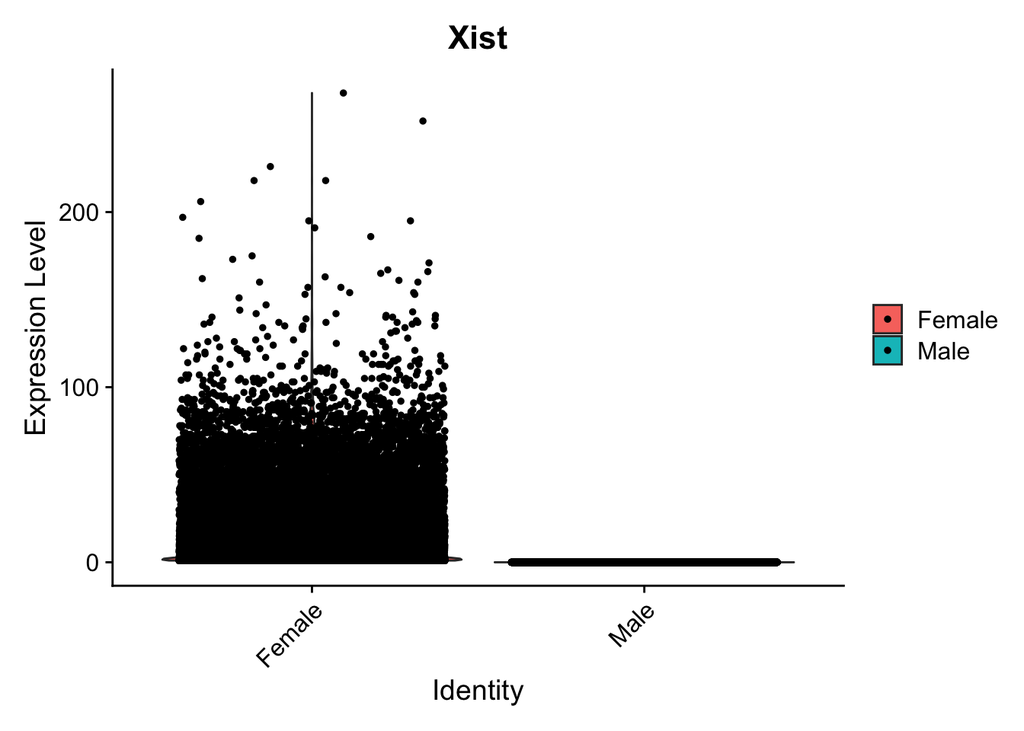

```r
if (organism %in% c("Human","Mouse","Rat")){
  if (organism == "Human") {
    sexgene = "XIST"
  } else {
    sexgene = "Xist"
  }
  sex = GetAssayData(sobject,slot = "counts")[sexgene,]
  sex[sex>0] = "Female"
  sex[sex != "Female"] = "Male"
  #add in a new metadata column
  sobject$sex = sex
  #Check with a violin plot
  VlnPlot(sobject,sexgene,group.by = "sex")
}
```

*QC - decide on final filtering parameters, look for clear outliers/differences between samples.*

1. Function to make an annotated violin plot

```r
anno_vln = function(seurat_object = sobject, metric = "nCount_RNA", group = "orig.ident"){
  #specify number of categories
  n = length(levels(seurat_object@meta.data[,group]))

  #make a violin plot
  a = VlnPlot(seurat_object,metric,group.by = group,pt.size = 0,log = F,cols = rep("lightgrey",n))

  #make a simple function that quantifies percentiles for each column
  add.percentiles = function(x) {
    r = quantile(x, probs = seq(0,1,0.2))
    r
  }

  a + geom_boxplot(width = 0.05,outlier.size = 0,notchwidth = 10,notch = T) + theme_bw() + stat_summary(fun=add.percentiles, geom="point", pch="_", colour=c(rep(c("red3","purple","yellow","forestgreen","darkblue","grey"),n)), size=10)
}
```

Plot each metric. Red = 0%, Purple = 20%, Yellow = 40%, Black = 50%,Green = 60%, Blue = 80%, Grey = 100% percentile

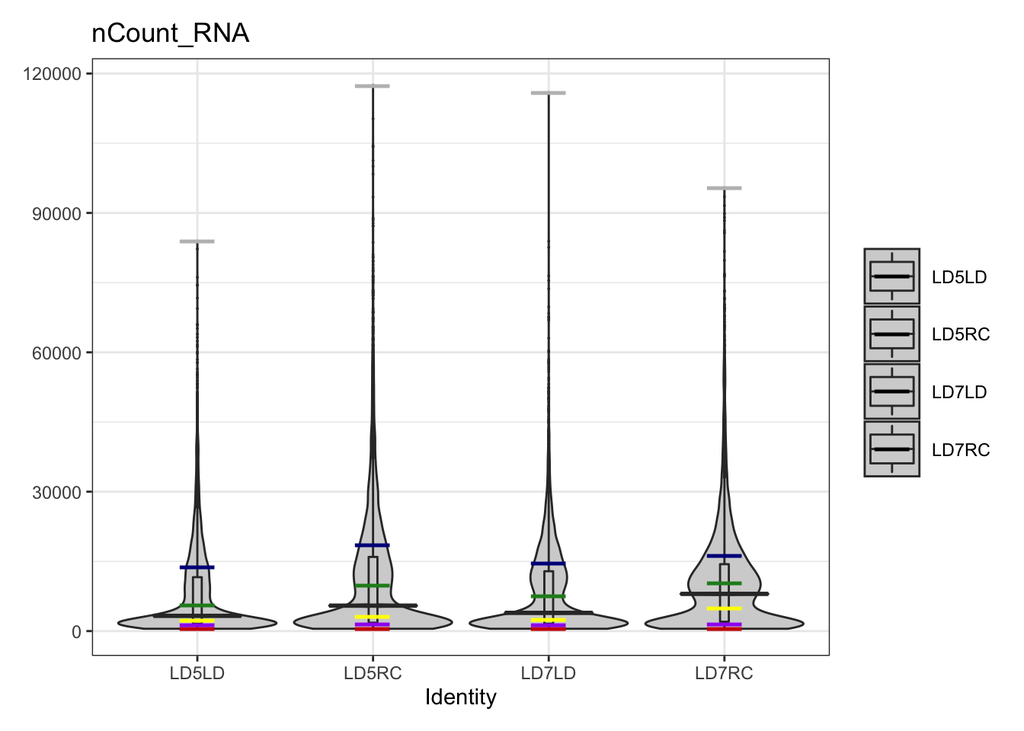

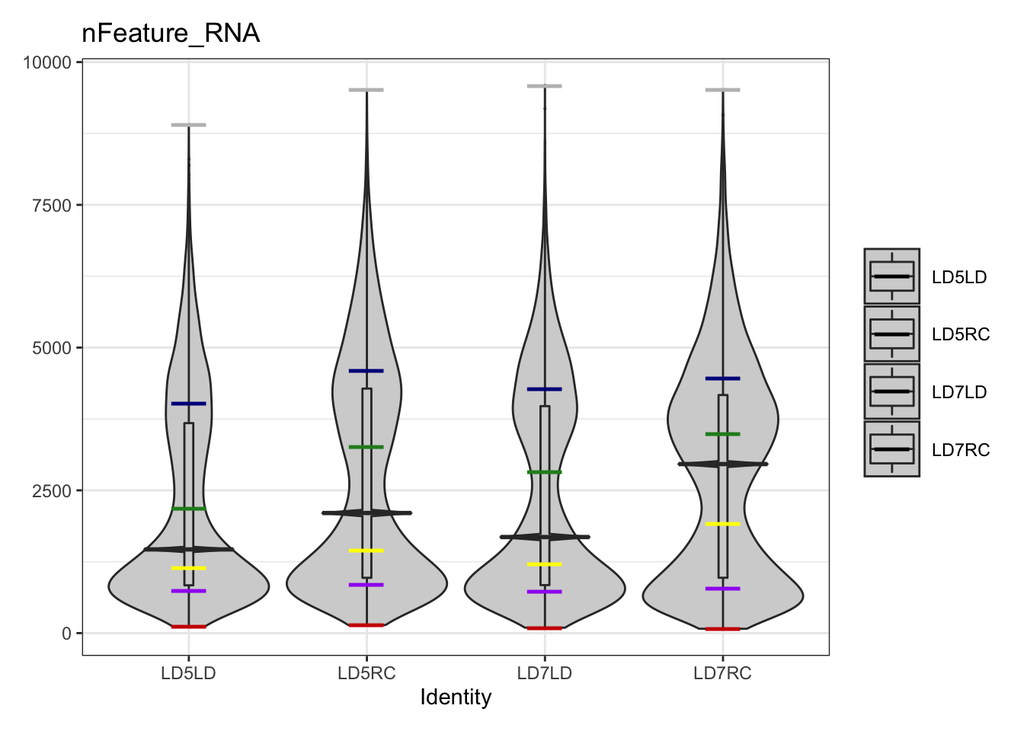

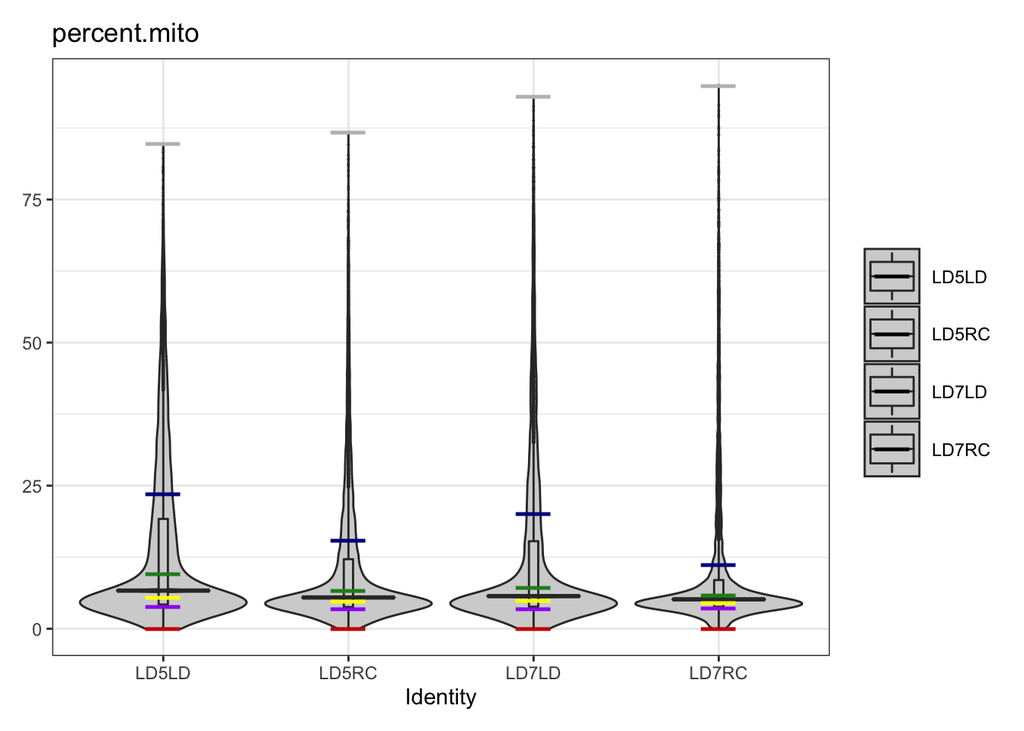

```r
#Save graphs
for (i in m){
  graph = anno_vln(metric = i)
  setEPS()
  postscript(file.path(dir,QCfolder,paste0(i,project,".eps")))
  print(graph)
  dev.off()
}

#print graphs to console
for (i in m){
  graph = anno_vln(metric = i)
  print(graph)
}
```

Plot the number of cells each gene is represented by - i.e. how many cells express any given gene? Ordered from rare to common genes. So you might consider focusing on genes that are relatively well expressed across the sample, or you might care about genes expressed only in a small subset of cells. The >=2 refers to read number per cell.

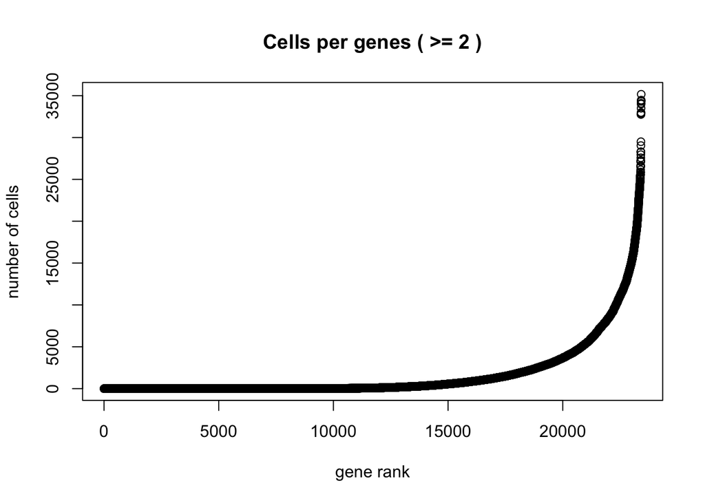

```r
plot(sort(Matrix::rowSums(GetAssayData(sobject)>=2)),xlab="gene rank",ylab="number of cells",main="Cells per genes ( >= 2 )")
```

A. Gene Plot, scatter plot of gene expression across cells, (colored by sample) - sequencing depth relative to genes; looking for similarity across samples. Some cell types can have relatively few genes, but highly expressed, could show up as a second arc below the one seen here (should contain all samples though) B. % Mitochondrial RNA vs Feature counts

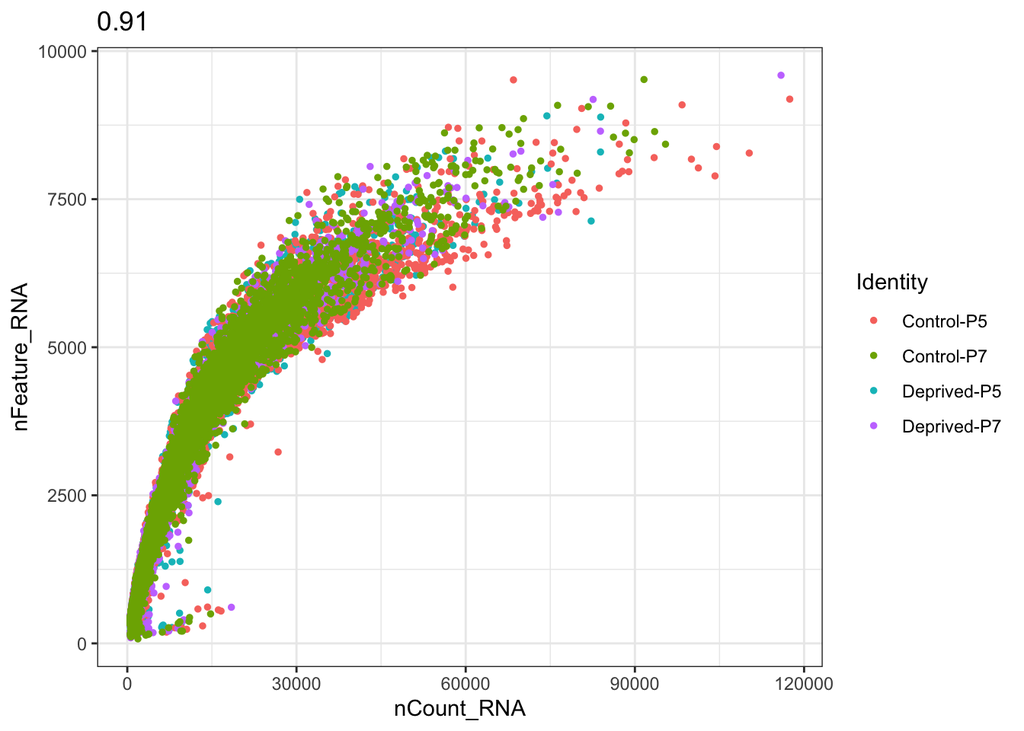

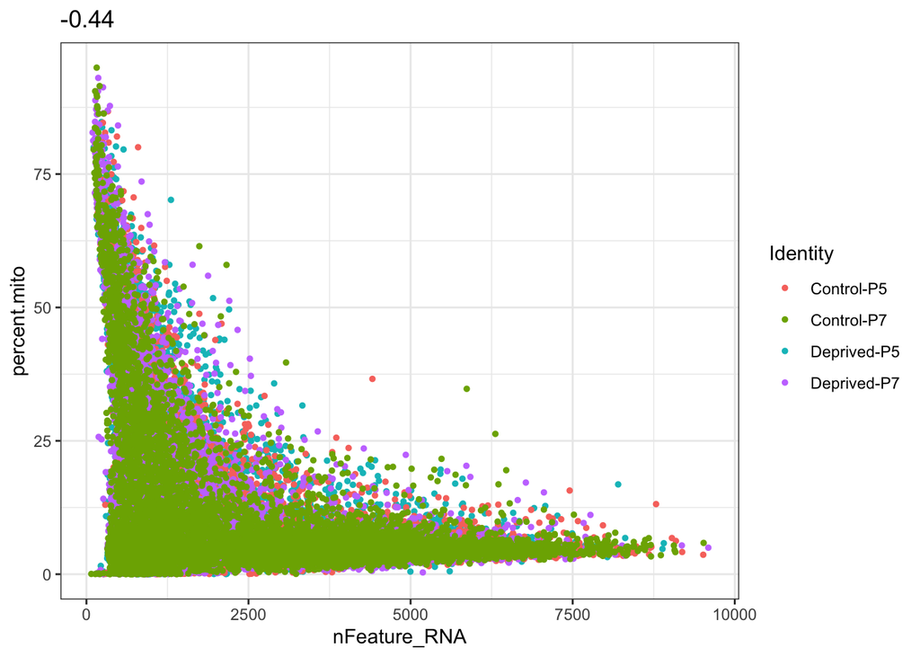

```r
Idents(sobject) = "sample_description"
#Save graphs
for (i in 1:(length(m)-1)){
  graph = FeatureScatter(sobject,m[i],m[i+1])+ theme_bw()
  setEPS()
  postscript(file.path(dir,QCfolder,paste0(m[i],"_",m[i+1],project,"scatter.eps")))
  print(graph)
  dev.off()
}

#print graphs
for (i in 1:(length(m)-1)){
  graph = FeatureScatter(sobject,m[i],m[i+1])+ theme_bw()
  print(graph)
}
```

Set limits based on the graphs

```r
mlo = 0.0000
mhi = 7.5
clo = 5000
chi = 35000
flo = 2500
fhi = 7500
```

Violin plot of 1) number of genes, 2) number of UMI and 3) percent mitochondrial genes; save with lines that show cutoffs

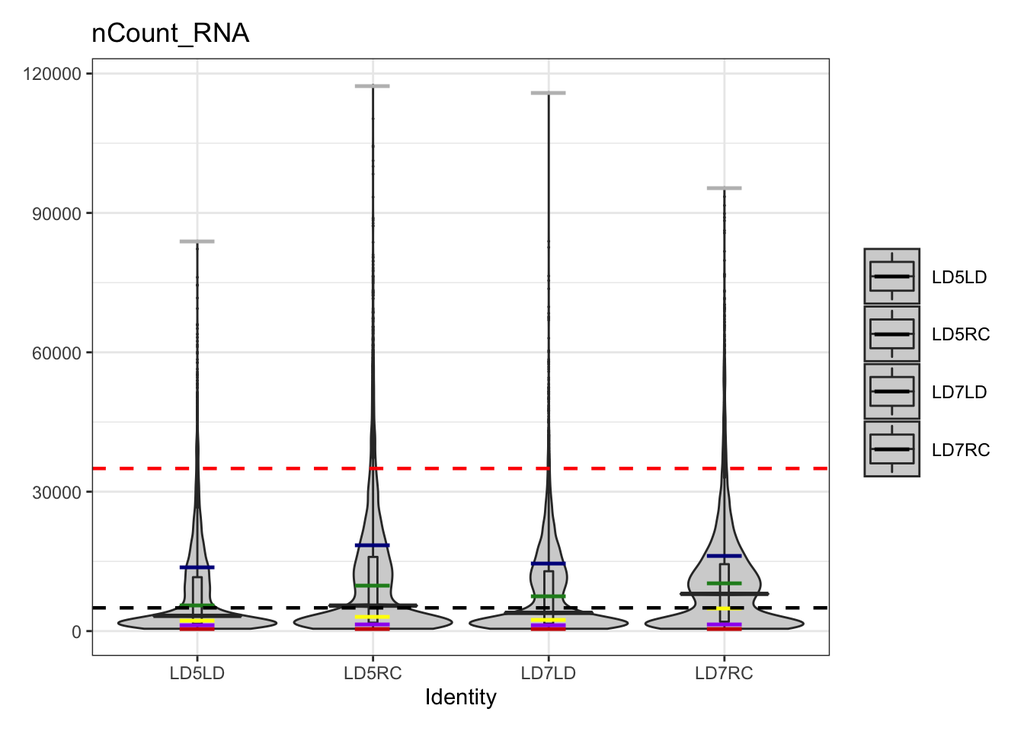

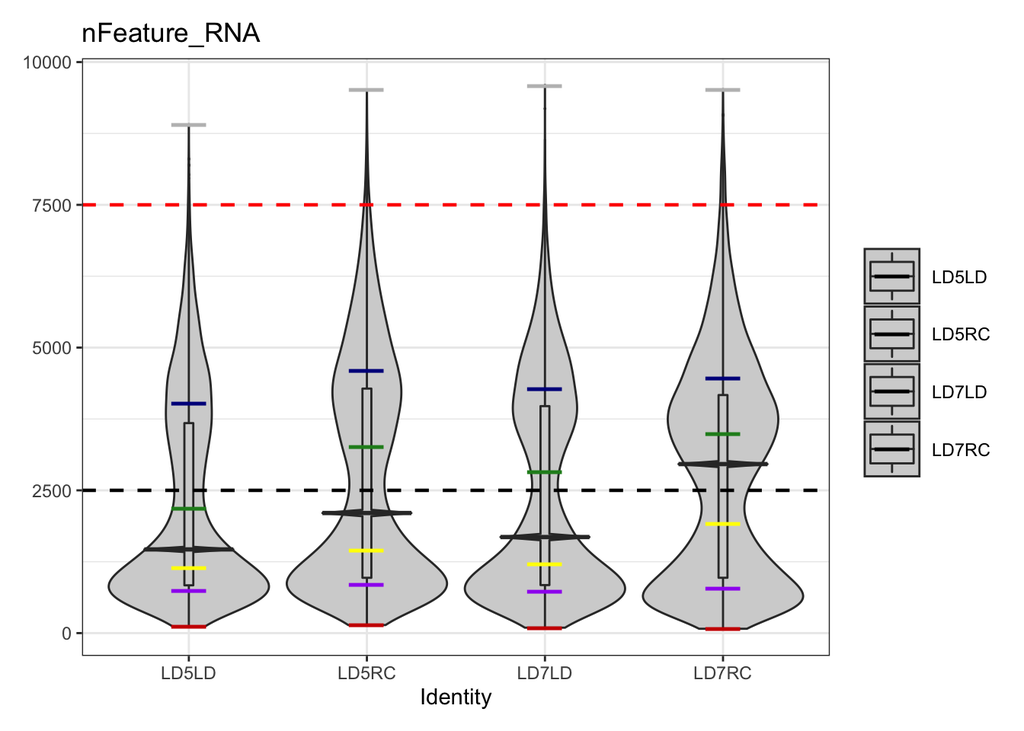

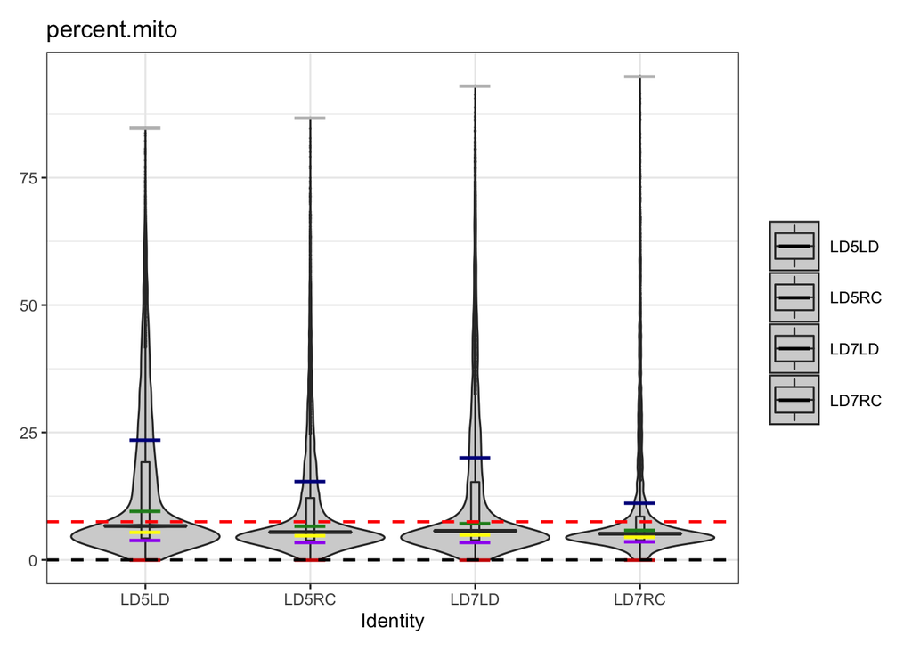

```r
group = "sample_description"
#Make a table with your cutoff values
tablelow = c(clo,flo,mlo)
tablehigh = c(chi,fhi,mhi)
t = as.data.frame(rbind(tablelow,tablehigh))
colnames(t) = m


#save graphs
for (i in 1:ncol(t)){
  metric = colnames(t)[i]
  low = t[1,i]
  high = t[2,i]
  graph = anno_vln(metric = metric) + geom_abline(intercept = high, slope = 0, linetype = "dashed",color = "red", size = 0.8) + geom_abline(intercept = low, slope = 0, linetype = "dashed",color = "black", size = .8)
  setEPS()
  postscript(file.path(dir,QCfolder,paste0(colnames(t)[i],project,"withcutoffs.eps")))
  print(graph)
  dev.off()
}

#print graphs
for (i in 1:ncol(t)){
   metric = colnames(t)[i]
  low = t[1,i]
  high = t[2,i]
  graph = anno_vln(metric = metric) + geom_abline(intercept = high, slope = 0, linetype = "dashed",color = "red", size = 0.8) + geom_abline(intercept = low, slope = 0, linetype = "dashed",color = "black", size = .8)
  print(graph)
}
```

Scatter plots with lines to show cutoffs

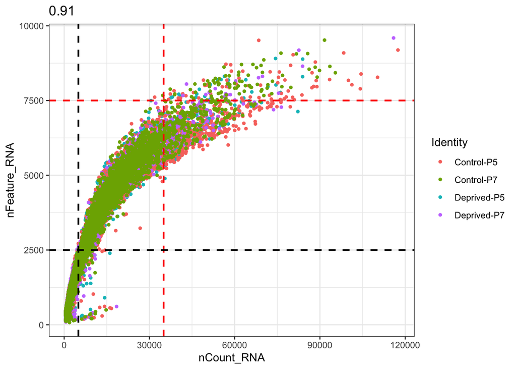

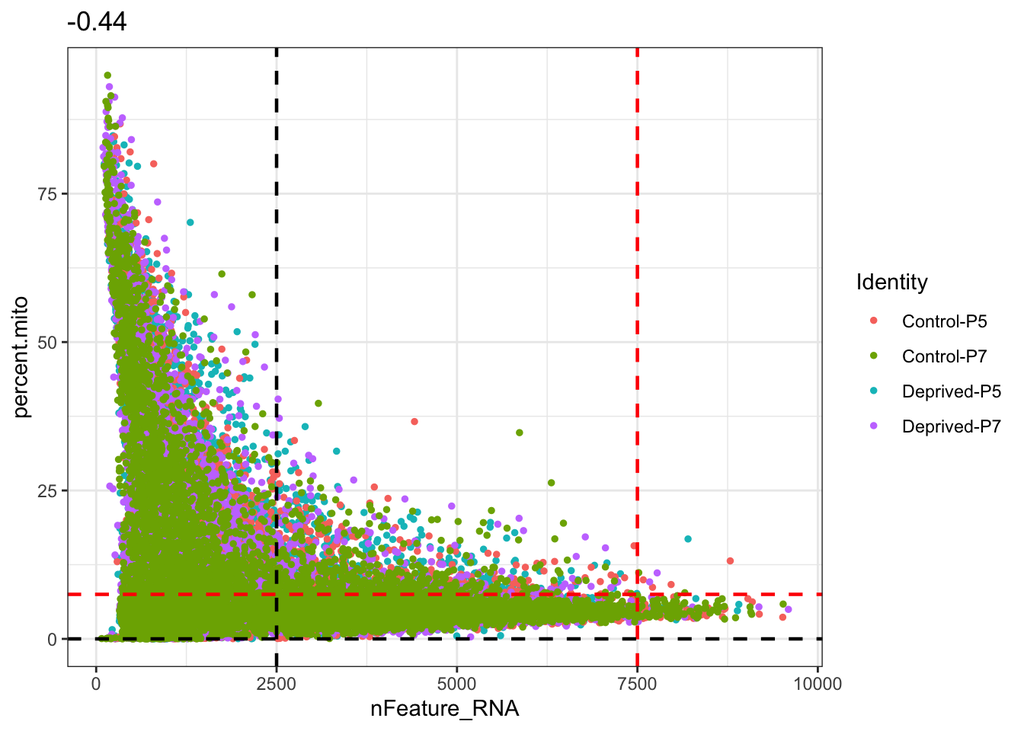

```r
#Save graphs
for (i in 1:(length(colnames(t))-1)){
  xm = colnames(t)[i]
  ym = colnames(t)[i+1]
  xlow = t[1,i]
  xhigh = t[2,i]
  ylow = t[1,i+1]
  yhigh = t[2,i+1]
  graph = FeatureScatter(sobject,xm,ym)+ theme_bw() + geom_vline(xintercept = xlow, linetype = "dashed",color = "black", size = .8) + geom_vline(xintercept = xhigh, linetype = "dashed",color = "red", size = .8)+ geom_hline(yintercept = ylow, linetype = "dashed",color = "black", size = .8)  + geom_hline(yintercept = yhigh, linetype = "dashed",color = "red", size = .8)
  setEPS()
  postscript(file.path(dir,QCfolder,paste0(m[i],"_",m[i+1],project,"scatter_withcutoffs.eps")))
  print(graph)
  dev.off()
}

#print graphs
for (i in 1:(length(colnames(t))-1)){
  xm = colnames(t)[i]
  ym = colnames(t)[i+1]
  xlow = t[1,i]
  xhigh = t[2,i]

  ylow = t[1,i+1]
  yhigh = t[2,i+1]

  graph = FeatureScatter(sobject,xm,ym)+ theme_bw() + geom_vline(xintercept = xlow, linetype = "dashed",color = "black", size = .8) + geom_vline(xintercept = xhigh, linetype = "dashed",color = "red", size = .8)+ geom_hline(yintercept = ylow, linetype = "dashed",color = "black", size = .8)  + geom_hline(yintercept = yhigh, linetype = "dashed",color = "red", size = .8)
  print(graph)
}
```

How to select filters??? noise vs signal - get them from the violin plots and the matrix, capture the bulk of cells but exclude outliers (say with mtDNA filter) - can also look at percentiles, maybe get rid of top 5% since it was very different from the rest. Basically eliminate outliers and don’t include cells that have hardly any genes or have a ton of genes expressed. First save the original object:

```r
save(sobject,file = file.path(dir,"Data/Seurat",paste0(project,"_beforeQC.RData")))
```

Subset the data. Printing tables lets you see the progression as you tighten your QC cutoffs.

```r
print("initial")
```

```
## [1] "initial"
```

```r
table(sobject$sample_description) #print out initial cell counts
```

```
##
##  Control-P5  Control-P7 Deprived-P5 Deprived-P7
##        8607        9265        9532        7855
```

```r
sobject = subset(sobject, subset = percent.mito>mlo & percent.mito < mhi) #subset mitochondria
print("mito")
```

```
## [1] "mito"
```

```r
table(sobject$sample_description) #new cell counts
```

```
##
##  Control-P5  Control-P7 Deprived-P5 Deprived-P7
##        5540        6578        5134        4808
```

```r
sobject = subset(sobject, subset = nCount_RNA>clo & nCount_RNA < chi)
print("ncount")
```

```
## [1] "ncount"
```

```r
table(sobject$sample_description)
```

```
##
##  Control-P5  Control-P7 Deprived-P5 Deprived-P7
##        3362        4536        2966        2970
```

```r
sobject = subset(sobject, subset = nFeature_RNA>flo & nFeature_RNA < chi)
print("nfeature")
```

```
## [1] "nfeature"
```

```r
table(sobject$sample_description)
```

```
##
##  Control-P5  Control-P7 Deprived-P5 Deprived-P7
##        3140        4299        2799        2824
```

```r
save(sobject, file = file.path(dir,"Data/Seurat",paste0(project,"_filtered.RData")))
```